# Homework 2 Sample Solutions

DKU Stats 101 Fall 2021

Anonymous

10/13/2021

## Q1: Literature review (5 points)

Find a news article online that discusses how to build a good Magic draft deck for either of the last two formats mentioned in the introduction and also post it to the Slack `#chat-and-interesting-materials` channel. Read and comment on a few other articles that other students have posted. Based on these articles, what should we expect to find in this dataset and why? Make a bulleted list below with specific expectations according to the data we have in our dataset.

> Any reasonable article will work here

## Q2: Confidence intervals (30 points)

### Q2a: Proportion of decks where green is a major color

- Find the 95% confidence interval of the proportion of decks for this player that have green `G` as a major color - calculate this by hand and show your work

> Formula: $p\pm z^*\times SE$ or $0.4412\pm 1.96\times \sqrt{\frac{0.4412\times0.5588}{238}}$

> $0.4412 - 1.96 \times 0.0322, 0.4412 + 1.96 \times 0.0322$

> $0.3781, 0.5043$
- Check the conditions of the confidence interval

> Conditions: Independence, Randomization, 10% Condition, Success/Failure Condition
> - Independence: yes, seems so
> - Randomization: yes
> - 10% condition: yes, we are sampling less than 10% of all possible matches this player could play
> - Success/failure: both proportions are over 10
- Interpret your confidence interval

> We are 95% confident that the true proportion of green decks this player plays is between 37.81% and 50.43%
- What sample size would you need to say with 95% confidence that true proportion lies within a plus/minus 0.01 range?

> $0.01 = 1.96 \times \sqrt{\frac{0.4412 \times 0.5588}{n}}$

> $0.01 \times \sqrt{n} = 1.96 \times \sqrt{0.4412 \times 0.5588}$

> $\sqrt{n} = \frac{1.96 \times \sqrt{0.4412 \times 0.5588}}{0.01}$

> ~9471

### Q2b: Trophy rate

- Find the 90% confidence interval of the proportion of decks that received a trophy

> Formula: $p\pm z^*\times SE$ or $0.0798\pm 1.64\times \sqrt{\frac{0.0798\times0.9202}{238}}$

> $0.0798 - 1.64 \times 0.0176, 0.0798 + 1.64 \times 0.0176$

> Answers may vary here but, for example, if the coach was estimating the chance the player could quit his/her job and become a professional. The player may be risk adverse and therefore only wish to quit that person’s job if the odds of not being a failure could be excluded. You must provide some justification for why a researcher on this question would be interested in making it harder to reject the null hypothesis.

### Q2c: Number of wins at Diamond rank

- Make a histogram of the number of wins per deck when the player is at Diamond rank - what does this histogram indicate about the suitability of the data for making a confidence interval of number of wins?

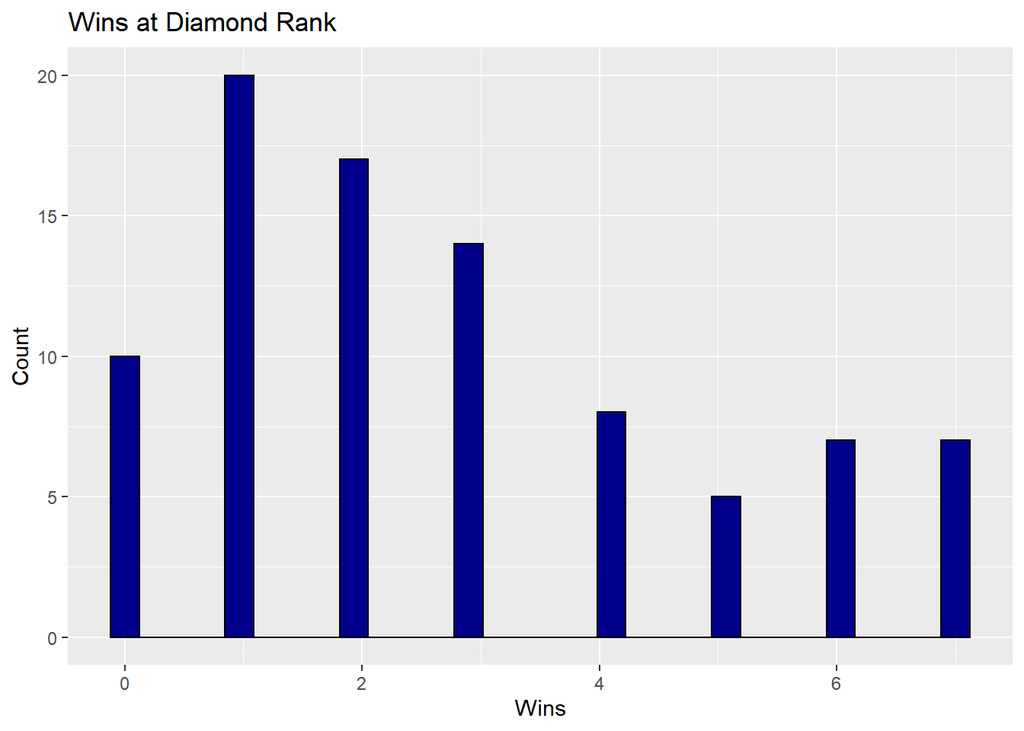

> Formula: $\hat{wins}_{mean}\pm t_{n-1}^*\times SE$ or $2.77\pm 1.99\times \frac{2.1}{\sqrt{88}}$

> $2.77 - 1.99 \times 0.22, 2.77 + 1.99 \times 0.22$

> $2.33, 3.21$
- Check the conditions of the confidence interval

> Conditions: Randomization/Independence, Nearly normal
> - Randomization, yes
> - Nearly normal, not really but due to CLT, is ok
- Interpret your confidence interval

> We are 95% confident that the true mean number of wins at diamond rank for this player is between 2.33 and 3.21
- How much larger would $n$ have to be to decrease by a factor of four the size of your confidence interval?

> It would have to be 16 times larger. The size of the confidence interval decreases according to the square of the sample size.
- Practically speaking, what does this confidence interval indicate - what can we understand about the average number of wins when at diamond rank?

> Answers may vary, but must make some statement beyond simply restating the confidence interval - something like the average number of wins is relatively narrow/large or some statement about the player capabilities.

### Q2d: Bootstrapping wins at Diamond rank

- Using the existing data, create a 95% bootstrapped confidence interval for the number of wins at diamond rank and show the code you used to create the bootstrapped confidence interval

```r
library(infer)

diamond.wins.ci <- diamond.results %>%
  specify(response=W) %>%
  generate(reps=100000, type="bootstrap") %>%
  calculate(stat="mean") %>%
  get_confidence_interval(level = 0.95, type = "percentile")

kable(diamond.wins.ci, col.names = c("Lower Bound", "Upper Bound"))
```

| Lower Bound | Upper Bound |
| --- | --- |
| 2.340909 | 3.215909 |

- Compare the results of the bootstrapped confidence interval (with 100000 samples) to you calculated by hand in Q2c - what can you conclude from the difference?

> The values are fairly similar (only off by a small amount); likely because the original sample met the conditions for confidence intervals. It also indicates that bootstrapping also works well to create confidence intervals.
- When would using the bootstrap method be helpful? When would the regular confidence interval be more useful?

> The bootstrap method may be more helpful if our data does not meet some of the conditions of confidence intervals. If the data meet the conditions for using a mathematical method for calculating confidence intervals, using it may be faster and more theoretically accurate than bootstrapping.

## Q3: Hypothesis testing (25 points)

### Q3a Proportion of decks for each color in `STX`

- Make a table and write out a specific hypothesis, fully specified, as to whether the proportion of decks that this player has played that each color in `STX` is different or not than the overall population of 17Lands users.

| Null Hypothesis | Alternative Hypothesis |
| --- | --- |
| $Pr(Player_W)=Pr(Pop_W)$ | $Pr(Player_W)\neq Pr(Pop_W)$ |
| $Pr(Player_U)=Pr(Pop_U)$ | $Pr(Player_U)\neq Pr(Pop_U)$ |
| $Pr(Player_B)=Pr(Pop_B)$ | $Pr(Player_B)\neq Pr(Pop_B)$ |
| $Pr(Player_R)=Pr(Pop_R)$ | $Pr(Player_R)\neq Pr(Pop_R)$ |
| $Pr(Player_G)=Pr(Pop_G)$ | $Pr(Player_G)\neq Pr(Pop_G)$ |

- What do you think is a reasonable critical value to select in this case? Choose your own critical value for your hypotheses tests.

> Answers may vary, remember that a critical value is the $z^*$ value, not $\alpha$
- In this case should you use a one-sided test or two-sided test?

> Two sided since we don’t have any reason to be only interested in errors in one direction
- Do these test pass the conditions for a hypothesis test?
> - Randomization, Independence: yes, somewhat. The independence condition may be violated in a group comparison
> - 10% Condition: yes
> - Nearly normal condition: depends on the sample
- Find the $p$ value for the difference for each color and interpret it with respect to your hypotheses tests.

| Null Hypothesis | Alternative Hypothesis | Pop Mean | Player Mean | $p$ value | Decision |
| --- | --- | --- | --- | --- | --- |
| $Pr(Player_W)=Pr(Pop_W)$ | $Pr(Player_W)\neq Pr(Pop_W)$ | 0.481 | 0.489 | 0.894 | Fail to reject |
| $Pr(Player_U)=Pr(Pop_U)$ | $Pr(Player_U)\neq Pr(Pop_U)$ | 0.360 | 0.540 | 0.002 | Reject |
| $Pr(Player_B)=Pr(Pop_B)$ | $Pr(Player_B)\neq Pr(Pop_B)$ | 0.475 | 0.504 | 0.628 | Fail to reject |
| $Pr(Player_R)=Pr(Pop_R)$ | $Pr(Player_R)\neq Pr(Pop_R)$ | 0.362 | 0.396 | 0.600 | Fail to reject |
| $Pr(Player_G)=Pr(Pop_G)$ | $Pr(Player_G)\neq Pr(Pop_G)$ | 0.323 | 0.424 | 0.098 | Fail to reject |

- What are, if any, the problems with analyzing the results of five simultaneous hypotheses tests like this?

> One obvious problem is that the choice of colors is not independent; colors are selected to pair with each other. So the most popular color pair will influence both colors in the hypothesis test. A related problem is that if one color is selected, this will mean that other colors must be necessarily chosen less frequently.

### Q3b `AFR` win rate

> Note the text of the question has changed from the original assignment
- Write out a specific hypothesis, fully specified with correct notation, as to whether the player’s `AFR` win rate is different than the 17Lands user `AFR` win rate.

> $H_0: \mu = 0.552$, $H_a: \mu \neq 0.552$
- If we observed that the number of wins is different from the population mean at $p$=0.06, should we reject the null hypothesis? Why or why not?

> Without a cutoff p value ($\alpha$), we can’t really say.
- In this case, is it more appropriate to use a one-sided or two-sided test?

> Two sided since we don’t have any reason to be only interested in errors in one direction
- Does this test pass the conditions for hypothesis testing?
> - Independence: yes, seems so
> - Randomization: yes, seems so
> - 10% condition: yes, we are sampling less than 10% of all possible matches this player could play
> - Success/failure: both $p$ and $q$ are over 10
- Find the $p$ value for the difference between the player’s games and the population mean. What can you conclude?

| $p$ value | Conclusion |
| --- | --- |
| 0.002 | Reject at $\alpha=0.05$ |

- What might be some possible lurking variables that might cause this difference (or non difference)? It is ok to speculate but try to be sensible.

> Answers will vary here, one possible lurking variable is that the player’s rank matters - the average rank of 17Lands players may be at a lower rank where it is easier to get wins compared to the player being analyzed here.

## Q4: Hypothesis testing wisdom (25 points)

### Q4a `STX` wins

- Write out the hypothesis for whether the average number of wins is different than the population mean

> $H_0: \mu = 0.549$, $H_a: \mu \neq 0.549$
- If we fail to reject the null hypothesis in this case, does that mean that the null hypothesis is true? Why?

> No, failing to reject the null hypothesis just means we don’t have enough evidence to say that the null hypothesis is not true.
- In your opinion, what $p$ value would you need to see to reject the null hypothesis

> Answers may vary but 0.05 is a reasonable starting point
- Based on the previous question, what would you set the alpha level to?

> Answers may vary but 0.05 is a reasonable starting point
- Let’s say the data suggests that you should reject the null hypothesis. What size of difference in wins would you need to see to feel there is a *practically* significant difference?

> Answers may vary here.
- By hand (show work), calculate your hypothesis test and interpret the results.

> pnorm(-3.425) = 0; 0*2 = p = 0

> We can reject the null hypothesis of no difference at a 0.05 level

### Q4b `RG` decks in `AFR`

- Write out the hypothesis for whether the player plays **more** `RG` decks (splashes included) in `AFR` as a proportion of the total than the average 17Lands user

> $H_0: \mu = 0.104$, $H_a: \mu > 0.104$
- Explain what the difference between a Type I and a Type II error is here
> - A type I: null is true but we mistakenly reject it. We conclude that the percentage of `RG` decks played by the player is greater than the population when it is actually the same
> - A type II: the alternative is true but we mistakenly fail to reject the null hypothesis. We do not conclude that the player plays more `RG` decks compared to the population when s/he actually does.
- Which error type do you think would be more serious for a coach trying to help this player? Why?

> Answers may vary. It isn’t obvious which is worse so any answer with a reasonable justification is ok.
- What are two ways we could reduce the possibility of a Type I error? What are the reasons we may not take those actions to reduce the error?

> We could increase the sample size or increase the power of the test by increasing alpha. Increasing the power of the test results in a greater chance of a Type I error. Increasing the sample size may increase the cost of the study.
- What is the power of this test?

> The power is $1-\beta$, where $\beta$ is the probability of committing a Type II error
- How large would a difference have to be to ‘matter’ in the context of being a coach?

> Answers may vary but I would consider something around 5% to start to be meaningful.
- By hand (show work), calculate your hypothesis test and interpret the results.

> ((0.1515152-0.104)/sqrt((0.104 * (1-0.104)) / 99)) -> about 1.549

> pnorm(1.549) = 0.061 (since a one-sided test)

> We cannot reject the null hypothesis of no difference at a 0.05 level

## Q5 Two sample $t$ and $z$ test (25 points)

### Trophy rate of decks featuring the color white `W` vs. black `B`

- Write appropriate hypotheses.

> $H_0: Trophy_W % = Trophy_B %$, $H_a: Trophy_W % \neq Trophy_B$
- Are the assumptions and conditions necessary for inference satisfied?
> - Independence: yes, seems so
> - Randomization: yes, seems so
> - Independent Groups: no, in particular, decks can be WB so we know already that the two groups have some overlap
> - Success/failure: both $p$ and $q$ are over 10
- Test the hypothesis and state your conclusion.

> ((0.0982143-0.0925926)/0.04 -> about 0.141

> pnorm(0.141) = 0.444; 0.444*2 = p = 0.888

> We cannot reject the null hypothesis of no difference at a 0.05 level
- Explain in this context what your $p$ value means.

> This conclusion has the risk of being a Type II error, in which we fail to reject the null hypothesis even though we should reject it. We could reduce this risk by increasing the sample size or increasing $\alpha$.
- Create a 95% confidence interval for the difference.

> 0.0982143 - 0.0925926 +- z* * 0.04

> -0.0727769, 0.0840203
- Interpret your interval from a statistical perspective and explain its practical meaning.

> We can be 95% confident that the difference between trophy rates of white and black decks for this player is between -0.0727769, 0.0840203

### `AFR` vs. `STX` wins at Diamond level

- Write out the hypothesis for whether the player has a higher number of average wins in `AFR` vs. `STX` at Diamond level.

> $H_0: \bar{Wins}_{AFR} = \bar{Wins}_{STX}, H_a: \bar{Wins}_{AFR} \neq \bar{Wins}_{STX}$
- Are the assumptions and conditions necessary for inference satisfied? Explain.
> - Independence: yes, seems so
> - Randomization: yes, seems so
> - Independent groups: seems unlikely that the two groups are truly independent
> - Nearly normal: roughly, yes

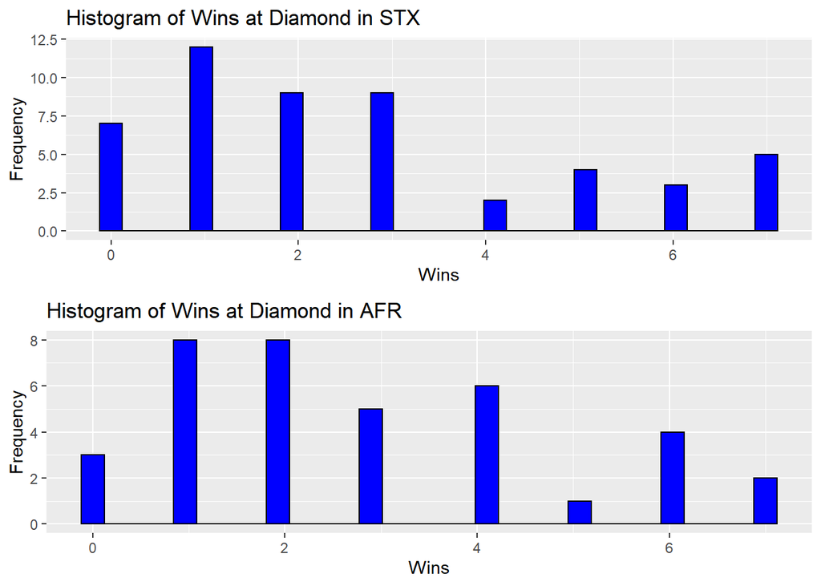

- In this case, should you be using pooled variance?

> Since this is a hypothesis of a difference in means (not proportions) and it is not an experiment, you should not be using pooled variance here.
- Create a 95% confidence interval for the difference in the average number of wins

> 2.7058824 - 2.8648649 +- t(50)* * 0.312

> -0.776, 0.458
- Interpret your interval in this context.

> We are 95% confident that the true difference in win rates between STX and AFR is between -0.776, 0.458
- Does this confidence interval suggest that the average number of wins at diamond level is different between the two sets? Explain.

> We cannot reject the null hypothesis of no difference

## Q6: Putting it all together (25 points)

> Answers will vary